[O’Hara on GitHub](https://github.com/oharac)

# Examine hierarchical clustering methods for functional grouping

Compiled on Fri Jul 2 19:35:37 2021 by ohara

```r
knitr::opts_chunk$set(echo = TRUE, message = FALSE, warning = FALSE)

library(oharac)
oharac::setup()
library(randomForest)
library(cluster)
library(caret)
library(factoextra)
library(ggfortify)
source(here('fb_slb_fxns.R'))
```

# 1 Summary

Gather processed traits data and assemble into a dataframe. Apply a clustering algorithm to identify groupings: first, use Random Forest to create a dissimilarity matrix, then use Hierarchical clustering to identify groups of similar species.

# 2 Data

See individual trait scripts.

# 3 Methods

## 3.1 Assemble dataframe

Let’s limit to observations with mean gapfill of rank 3 (family) or lower. For now this gets us 17k observations. Limiting that to rank 4 (order) or lower gets us 64k observations, or perhaps it is more efficient to gapfill groups upwards? For Random Forest, use all traits in their rawest form (though there is some gapfilling already occurring in the trait prep scripts).

```r
gf_cut <- 3

trait_length <- read_csv(here('_data/traits_grouping/trait_length.csv')) %>%
  filter(gf_level <= gf_cut) %>%
  select(species, log_l = value)
trait_reprod <- read_csv(here('_data/traits_grouping/trait_reproduction_raw.csv')) %>%
  filter(gf_level <= gf_cut) %>%
  select(species, depend_score, log_gen_time, log_max_fecund, pld_score, protect_score)
trait_depth  <- read_csv(here('_data/traits_grouping/trait_depth_raw.csv')) %>%
  filter(gf_level <= gf_cut) %>%
  select(species, depth, terr_score, vert_mig_score)
trait_mobil  <- read_csv(here('_data/traits_grouping/trait_mobility.csv')) %>%
  filter(gf_level <= gf_cut) %>%
  select(species, mob_score = value)
trait_troph  <- read_csv(here('_data/traits_grouping/trait_trophic_level.csv')) %>%
  filter(gf_level <= gf_cut) %>%
  select(species, troph_level = value)
traits_df <- trait_length %>%
  full_join(trait_reprod) %>%
  full_join(trait_depth) %>%
  full_join(trait_mobil) %>%
  full_join(trait_troph)
```

```r
taxa <- read_csv(here('_data/vuln_data/vuln_gapfilled_tx.csv')) %>%
  select(class:species)

traits_dropna <- traits_df %>%
  left_join(taxa, by = 'species') %>%
  drop_na()
### leaves only 17008 observations...
```

## 3.2 Unsupervised Random Forest

Let’s apply the Random Forest process to the traits dataframe, without supervision, to create a proximity matrix. Drop some low-importance variables.

```r
### n = 1000, t = 3.663; n = 2000, t = 10.096; n = 17008, t = 477.686
system.time({
  unsup_rf <- randomForest(x = traits_dropna %>%
                             ### drop three least important vars
                             select(-terr_score, -vert_mig_score, -depend_score) %>%
                             # sample_n(2000) %>%
                             select(where(is.numeric)),
                           mtry = 3, ntree = 1000, proximity = TRUE)
})
```

```
##    user  system elapsed
## 461.523   6.680 468.209
```

```r
unsup_rf
```

```
##
## Call:
##  randomForest(x = traits_dropna %>% select(-terr_score, -vert_mig_score,      -depend_score) %>% select(where(is.numeric)), ntree = 1000,      mtry = 3, proximity = TRUE)
##                Type of random forest: unsupervised
##                      Number of trees: 1000
## No. of variables tried at each split: 3
```

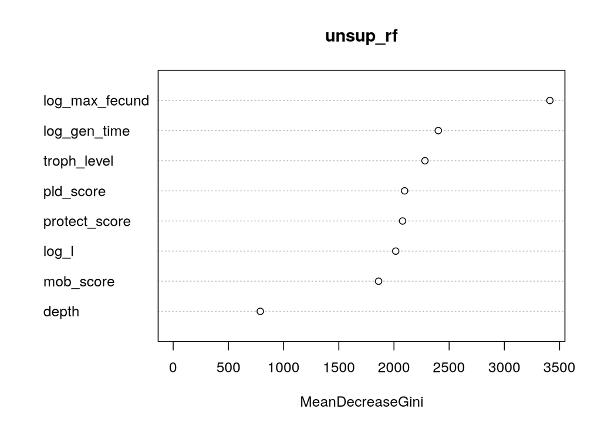

```r
varImpPlot(unsup_rf)
```

## 3.3 Hierarchical clustering

### 3.3.1 Notes on clustering techniques:

With the results of the unsupervised Random Forest, we tried clustering in two ways: Partitioning Around Medioids (which seems standard for Random Forest examples), and Hierarchical clustering (which also appears in some Random Forest examples). For these we identified a reasonable number of clusters and compared results; the most similar clusters scored about 80% on Jaccard similarity index.

### 3.3.2 identify an appropriate number of clusters

While hierarchical clustering doesn’t necessarily result in a specific number of clusters, we want to group species into discrete clusters as proxies for functional diversity. The silhouette method seems standard, and applicable across different clustering methods (counterexample, the gap statistic method seems to require Euclidean distances, which Random Forest does not provide(?))

We can use the Silhouette method for examining the relationship between number of clusters and average silhouette width.

From https://uc-r.github.io/kmeans_clustering:

> In short, the average silhouette approach measures the quality of a clustering. That is, it determines how well each object lies within its cluster. A high average silhouette width indicates a good clustering. The average silhouette method computes the average silhouette of observations for different values of *k*. The optimal number of clusters *k* is the one that maximizes the average silhouette over a range of possible values for *k*.

```r
avg_sil_hcl <- function(k, HC, DM) {
  ### k <- 6
  hclust_tree <- cutree(HC, k = k)
  ss <- silhouette(hclust_tree, dmatrix = DM)
  mean_sil_w <- mean(ss[, 'sil_width'])
}

loop_over_hclusts <- function(k_vec = 6:200, HC, DM) {
  message('Calculating hclust silhouette for ', nrow(traits_dropna),
          ' observations (gapfill = ', gf_cut, ')')

  avg_sil <- parallel::mclapply(k_vec,
                                FUN = avg_sil_hcl,
                                HC = HC,
                                DM = DM,
                                mc.cores = 8)
  avg_sil_val_vec <- unlist(avg_sil)

  silh_df <- data.frame(k = k_vec, silh = avg_sil_val_vec)
  return(silh_df)
}
```

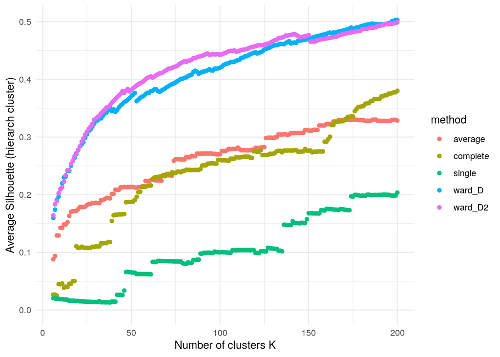

```r
### generate a dissimilarity matrix from the unsupervised random forest output.
prox_mtx <- unsup_rf$proximity
dissim_mtx <- 1 - prox_mtx
dist_mtx <- as.dist(dissim_mtx, diag = TRUE, upper = TRUE)

rf_hclust_ward1 <- hclust(dist_mtx, method = 'ward.D')
rf_hclust_ward2 <- hclust(dist_mtx, method = 'ward.D2')
rf_hclust_compl <- hclust(dist_mtx, method = 'complete')
rf_hclust_singl <- hclust(dist_mtx, method = 'single')
rf_hclust_avg   <- hclust(dist_mtx, method = 'average')
### from help: Ward's minimum variance method aims at finding compact,
### spherical clusters. The complete linkage method finds similar clusters.
### The single linkage method (which is closely related to the minimal
### spanning tree) adopts a ‘friends of friends’ clustering strategy. The
### other methods can be regarded as aiming for clusters with characteristics
### somewhere between the single and complete link methods

silh_df_ward1 <- loop_over_hclusts(HC = rf_hclust_ward1,
                                  DM = dissim_mtx)

silh_df_ward2 <- loop_over_hclusts(HC = rf_hclust_ward2,
                                  DM = dissim_mtx)

silh_df_compl <- loop_over_hclusts(HC = rf_hclust_compl,
                                  DM = dissim_mtx)

silh_df_singl <- loop_over_hclusts(HC = rf_hclust_singl,
                                  DM = dissim_mtx)

silh_df_avg <- loop_over_hclusts(HC = rf_hclust_avg,
                                DM = dissim_mtx)

silh_df_compare <- silh_df_ward1 %>%
  rename(ward_D = silh) %>%
  full_join(silh_df_ward2 %>% rename(ward_D2 = silh)) %>%
  full_join(silh_df_avg %>% rename(average = silh)) %>%
  full_join(silh_df_compl %>% rename(complete = silh)) %>%
  full_join(silh_df_singl %>% rename(single = silh)) %>%
  gather(method, silh, -k)

ggplot(silh_df_compare, aes(x = k, y = silh, color = method)) +
  geom_point() +
  labs(x = "Number of clusters K",
       y = "Average Silhouette (hierarch cluster)") +
  ylim(c(0, NA)) +
  theme_minimal()
```

```r
ggsave('figs/silhouette_plot.png')
```

#### 3.3.2.1 Plot of silhouettes including all traits

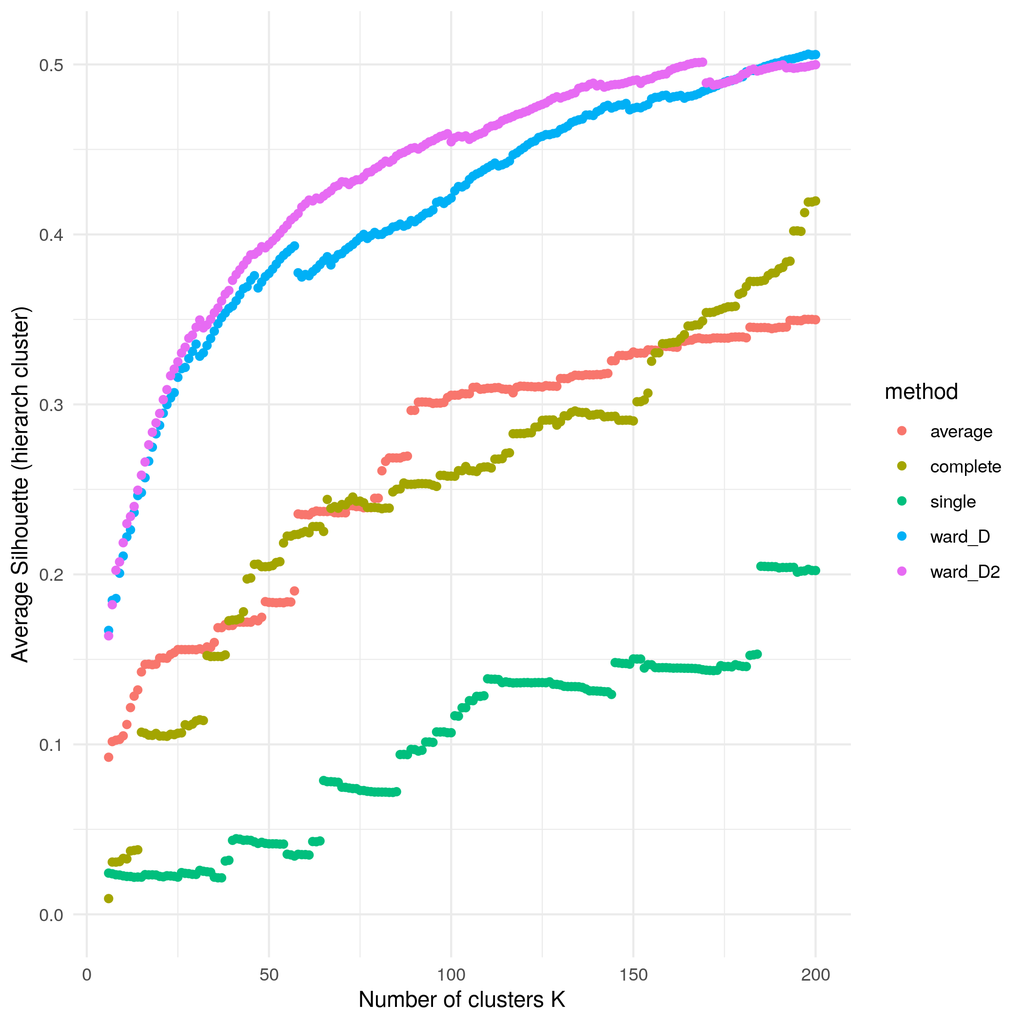

Clustering using different methods (Ward’s Distance 1 and 2, average, complete linkage, single linkage) from six up to 200 different clusters across the full set of traits (no least-important traits dropped), some observations:

- Wards D and D2 start near 0.15 and continue to increase with number of clusters; there are some little downward blips here and there (30-50 for D and ~170 for D2). They both approach 0.5 by the time 200 clusters have been reached and appear to still be increasing.
- Complete linkage shows discrete jumps at certain numbers of clusters, jumping to about 0.2 at 50 clusters, and then unevenly increasing to about 0.4 at 200 clusters.
- Single linkage starts near 0.025 and jumps up unevenly to about 0.04 at 40 clusters, and about 0.2 at around 180 clusters.
- Average linkage increases to about .18 by 50 clusters, about .35 by 200 clusters.

From this, the Wards distance methods show tighter clusters as evident from consistently higher silhouette scores.

#### 3.3.2.2 Plot of silhouettes dropping least important traits

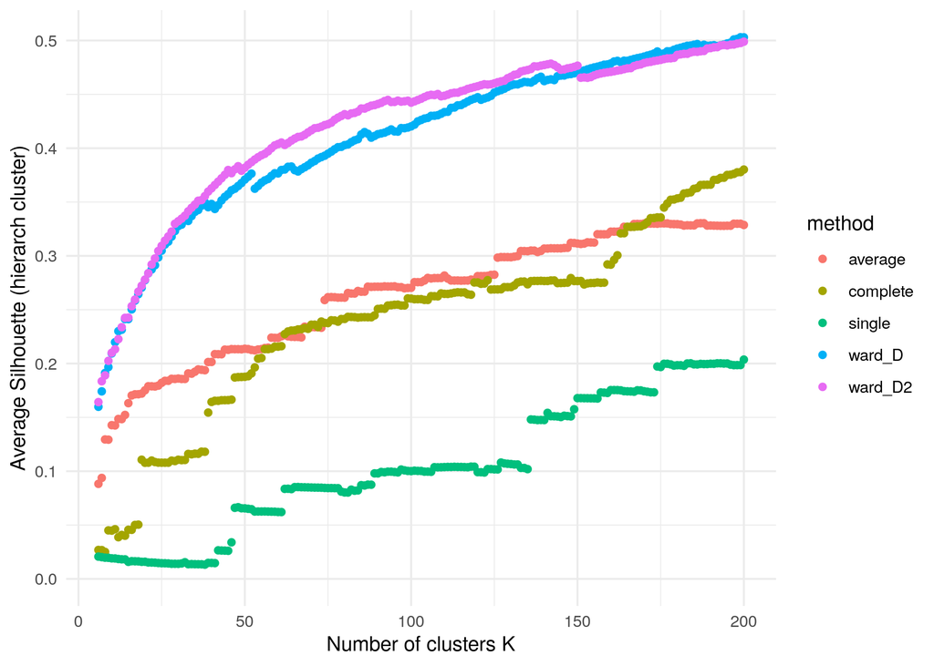

`vert_mig_score` and `terr_score` showed very small effects on reducing Gini scores